# Circular Statistics with BUGS

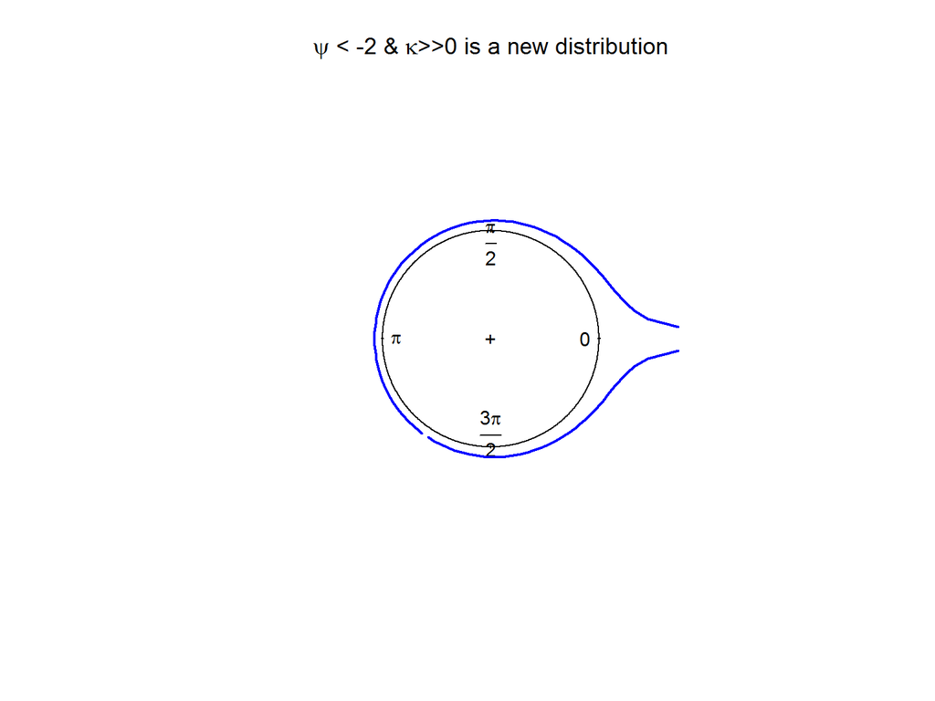

```r
ff <- function(x) djonespewsey(x, mu=0, kappa=10, psi=-3)
curve.circular(ff, col="blue", lwd=2, shrink = 2,
               main=expression(paste(psi," < -2 & ", kappa , ">>0 is a new distribution")))
```

The package `circular` does not provide a sampling function. The next code uses the method of acceptance-rejection to sample from it:

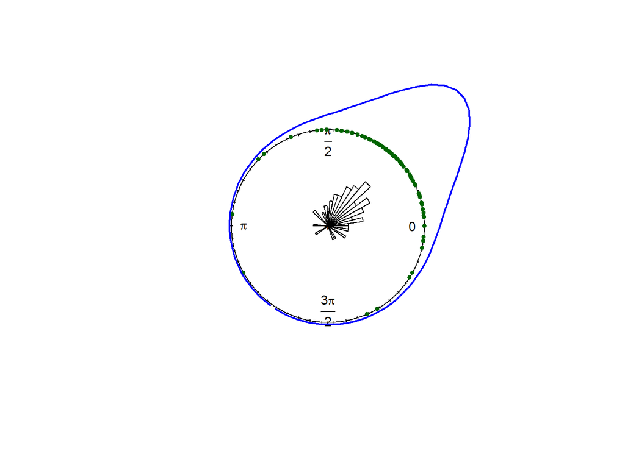

```r
# ref:   Circular Statistics in R,
# check: https://circstatinr.st-andrews.ac.uk/resources/Chap4-RCommands.txt
rjonespewsey <- function(n, mu, kappa, psi) {

  fmax  <- djonespewsey(mu, as.circular(mu), kappa, psi)
  theta <- 0

  for (j in 1:n) {
    stopgo <- FALSE
    while (!stopgo) {
      u1 <- runif(1, 0, 2*pi)
      pdfu1 <- djonespewsey(u1, as.circular(mu), kappa, psi)
      u2 <- runif(1, 0, fmax)
      if (u2 <= pdfu1) {
        theta[j] <- u1
        stopgo <- TRUE
      }
    }
  }

  as.circular(theta)
}

# Eg of use:
set.seed(121)
mu <- pi/4; kappa <- 2; psi <- -3/4
rdata <- rjonespewsey(100, mu=mu, kappa=kappa, psi=psi)
rose.diag(rdata, bins=50, prop=1.5, shrink=1.5)
points(rdata, pch=20, col="darkgreen")
ff <- function(x) djonespewsey(x, mu=mu, kappa=kappa, psi=psi)
curve.circular(ff, col="blue", lwd=2, add=T)
```

Concerning `circular::djonespewsey`, I did find some integration problems for specific values of ($\mu, \kappa, \psi$), like `djonespewsey(0,0,4.63,-1.61)` produces the error `Error in integrate(ker, 0, 2 * pi) : the integral is probably divergent`.

The package implementation is similar to this one:

```r
djonespewsey2 <- function(x, mu, kappa, psi) {
  ker <- function(x) {
    (cosh(kappa * psi) + sinh(kappa * psi) * cos(x - mu))^(1/psi)/
      (2 * pi * cosh(kappa * psi))
  }

  normalization <- integrate(ker, 0, 2 * pi)$value
  ker(x)/normalization
}

djonespewsey(0,0,4.63,-1.61)
```

```
## Error in integrate(ker, 0, 2 * pi): the integral is probably divergent
```

```r
djonespewsey2(0,0,4.63,-1.61)
```

```
## Error in integrate(ker, 0, 2 * pi): the integral is probably divergent
```

So, here’s a more stable density approximation without using `integrate`:

```r
my_djonespewsey <- function(x, mu, kappa, psi) {
  ker <- function(x) {
    (cosh(kappa * psi) + sinh(kappa * psi) * cos(x - mu))^(1/psi)/
      (2 * pi * cosh(kappa * psi))
  }

  dx = 0.01
  xs <- seq(0,2*pi,dx)
  normalization <- sum(ker(xs))*dx
  ker(x)/normalization
}

my_djonespewsey(0,0,4.63,-1.61)
```

```
## [1] 57.11161
```

Just an eg that the stable variant produces similar values to the package implementation:

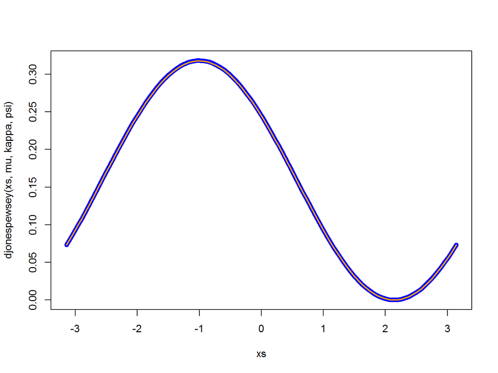

```r
mu <- -1; kappa <- 10; psi <- 1

xs <- seq(-pi,pi,len=100)
plot(xs, djonespewsey(xs,mu,kappa,psi), col="blue", lwd=7, type="l")
points(xs, my_djonespewsey(xs,mu,kappa,psi), col="orange", lwd=2, type="l")
```

## Stan Model

Due to the difficult normalization constant, I didn’t find a practical way to model this distribution on BUGS. The only possibility I see is to provide BUGS with a grid of values $(\kappa, \psi)$ computed by function `JPNCon`, and let BUGS chose the best pair value…

That way, I used Stan to implement the previous stable density, and so we can infer the parameters of this distribution, like we did previously.

```r
library(rstan)
```

This is the model in Stan:

```r
model <- '
  functions {

     // debug purposes
     // void print_xs(real[] xs) {
     //   int size_xs;

     //   size_xs <- size(xs);
     //   for(i in 1:size_xs) {
     //      print(xs[i])
     //   }
     // }

     real kernel(real x, real mu, real kappa, real psi) {

        return (cosh(kappa * psi) + sinh(kappa * psi) * cos(x - mu))^(1/psi) /
               (2 * pi() * cosh(kappa * psi));
     }

     real normalization(real dx, real[] xs, real mu, real kappa, real psi) {

        real value;
        int size_xs;

        size_xs <- size(xs);
        value   <- 0;
        for (i in 1:size_xs) {
           value <- value + kernel(xs[i], mu, kappa, psi);
        }
        return value*dx;
     }

     real JonesPewsey_log(real[] D, int N, real dx, real[] xs,
                          real mu, real kappa, real psi) {

        real log_lik;
        real log_pdf_const;

        log_pdf_const <- log( normalization(dx, xs, mu, kappa, psi) );
        log_lik <- 0;
        for(i in 1:N) {
          //log_lik <- log_lik + log( kernel(D[i], mu, kappa, psi)/pdf_const );
          log_lik <- log_lik + log( kernel(D[i], mu, kappa, psi) ) - log_pdf_const;
        }

        return log_lik;
     }
  }

  data {
    int<lower=0> N;   // number of observed data points
    real D[N];         // the observed data
  }

  transformed data {

    real<lower=0> dx; // should be a power of 10: 0.01, 0.001, ...
    real xs[100];     // should have size 1/dx

    dx <- 0.01;       // step to approximate integral with sums

    xs[1] <- 0;       // a grid of points between [0,2pi]
    for(i in 2:100)  {
      xs[i] <- xs[i-1] + 2*pi()*dx;
    }
    // print_xs(xs) // debug: to check if xs was correctly constructed
  }

  parameters {
    real<lower=-pi(), upper=pi()> mu;     // mu over the unit circle
    real<lower= 0,    upper=5>    kappa;  // kappa >= 0
    real<lower=-10,  upper=10>    psi;    // limited to [-10,10]
  }

  model {

    // priors
    mu    ~ uniform(-pi(),pi());
    kappa ~ uniform( 0,5);
    psi ~ uniform(-10,10);                // behaves better than psi ~ cauchy(0,10);

    // likelihood
    D ~ JonesPewsey(N, dx, xs, mu, kappa, psi);
  }
'
```

So, let’s try to fit some circular data samples. The next function receives parameter values for the Jones and Pewsey distribution, generates a ramdon sample from it, and then fit this sample (assuming the parameter values were unknown), and then plot the true distribution against the estimated one (ie, the distribution which parameter values are the posterior means):

```r
# place all angles between 0 <= mu < 2*pi
normalize_angles <- function(x) {
  while(x>2*pi)
    x = x-2*pi
  x
}

fit_and_plot <- function(mu, kappa, psi, N=75, iter=5000) {

  # step 1: create a random sample D
  set.seed(121)
  D <- as.numeric(rjonespewsey(N, mu=mu, kappa=kappa, psi=psi))
  D <- sapply(D, normalize_angles) # values between 0 <= mu < 2*pi

  # step 2: fit D using Stan's model
  fit  <- stan(model_code = model, data = list(D=D, N=N),  iter = 1000, chains = 1, verbose = FALSE)
  fit2 <- stan(fit = fit,          data = list(D=D, N=N),  iter = iter, chains = 2,
             verbose = FALSE, seed=101, warmup=1000)
  print(fit2)

  # step 2a: extract posterior means
  la <- extract(fit2, permuted = TRUE)
  mu_hat    <- mean(la$mu)
  kappa_hat <- mean(la$kappa)
  psi_hat   <- mean(la$psi)

  # step 3: plot
  # left panel
  par(mfrow=c(1,2))
  xs <- seq(-pi,pi,len=100)
  plot(xs, my_djonespewsey(xs,mu,kappa,psi), col="blue", lwd=4, type="l",
       xlab="x", ylab="density")
  points(xs, my_djonespewsey(xs,mu_hat,kappa_hat,psi_hat), col="red", lwd=2, type="l")
  # right panel
  plot(as.circular(D), shrink=1.25, col="darkgreen", pch=20)
  ff     <- function(x) my_djonespewsey(x, mu=mu, kappa=kappa, psi=psi)
  curve.circular(ff, col="blue", lwd=4, add=T)
  ff_hat <- function(x) my_djonespewsey(x, mu=mu_hat, kappa=kappa_hat, psi=psi_hat)
  curve.circular(ff_hat, col="red", lwd=2, add=T)
  legend("topleft",c("real","estimate"), col=c("blue","red"), lwd=2, bty = "n")
  par(mfrow=c(1,1))

  # return true parameters and point estimates
  data.frame(true=c(mu, kappa, psi), estimate=c(mu_hat, kappa_hat, psi_hat))
}
```

Fitting a distribution close to a von Mises:

[output not shown]

[output cut: 13 more lines]

```
##
## Inference for Stan model: 23368f84e08f2ce0726de8466b4ef4d3.
## 2 chains, each with iter=2500; warmup=1000; thin=1;
## post-warmup draws per chain=1500, total post-warmup draws=3000.
##
##        mean se_mean   sd  2.5%   25%   50%   75% 97.5% n_eff Rhat
## mu     0.84    0.00 0.08  0.68  0.79  0.84  0.89  1.00   769    1
## kappa  3.91    0.03 0.72  2.36  3.43  3.98  4.51  4.95   500    1
## psi    0.15    0.00 0.09 -0.07  0.10  0.16  0.21  0.32   447    1
## lp__  64.57    0.05 1.37 61.20 63.96 64.95 65.57 66.10   660    1
##
## Samples were drawn using NUTS(diag_e) at Sat Oct 03 20:10:09 2015.
## For each parameter, n_eff is a crude measure of effective sample size,
## and Rhat is the potential scale reduction factor on split chains (at
## convergence, Rhat=1).
```

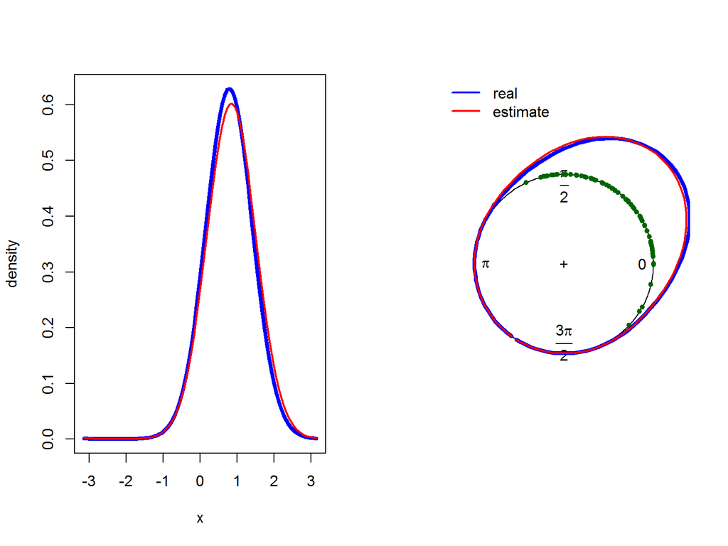

```
##        true  estimate
## 1 0.7853982 0.8416541
## 2 4.0000000 3.9106862
## 3 0.1250000 0.1507968
```

```r
fit_and_plot(mu=pi/4,  kappa=4, psi=1/8, iter=2500)
```